# Feature Engineering In-Class Activity - SOLUTIONS

Predicting Student Performance

Instructor Solutions

2025-09-23

## Overview

In this 40-minute activity, you’ll apply feature engineering techniques to a student performance dataset. Your goal is to create new features that better predict a student’s final grade using the techniques covered in today’s lecture.

## Learning Objectives

By the end of this activity, you should be able to: - Create new features from existing variables using domain knowledge - Apply one-hot encoding to categorical variables - Generate interaction terms and polynomial features - Evaluate feature effectiveness using correlation analysis - Visualize relationships between engineered features and target variables

## Setup

First, let’s load the required libraries and generate our dataset.

```r
library(tidyverse)
library(lubridate)
library(fastDummies)

# Set seed for reproducibility
set.seed(456)
```

## The Dataset

We’ll work with a student performance dataset containing information about 400 students.

```r
# Generate student performance dataset
n <- 400

student_data <- tibble(
  student_id = 1:n,
  study_hours_per_week = round(runif(n, min = 2, max = 25)),
  attendance_rate = round(runif(n, min = 60, max = 100)),
  previous_grade = round(runif(n, min = 65, max = 95)),
  major = sample(c("STEM", "Liberal Arts", "Business", "Arts"), n, replace = TRUE,
                 prob = c(0.3, 0.25, 0.25, 0.2)),
  semester_start_date = ymd("2024-01-15") + days(round(runif(n, min = -10, max = 10))),
  has_job = sample(c("Yes", "No"), n, replace = TRUE, prob = c(0.4, 0.6)),
  class_level = sample(c("Freshman", "Sophomore", "Junior", "Senior"), n, replace = TRUE)
) %>%
  mutate(
    # Create final_grade with complex relationships
    final_grade = pmax(50, pmin(100,
      70 +
      study_hours_per_week * 0.8 +
      (attendance_rate - 80) * 0.15 +
      (previous_grade - 80) * 0.2 +
      case_when(
        major == "STEM" ~ 2,
        major == "Business" ~ 1,
        major == "Liberal Arts" ~ 0,
        major == "Arts" ~ -1
      ) +
      ifelse(has_job == "Yes", -3, 0) +
      # Add interaction effects
      (study_hours_per_week - mean(study_hours_per_week)) *
      (attendance_rate - mean(attendance_rate)) * 0.01 +
      rnorm(n, mean = 0, sd = 5)
    ))
  )

# Display the dataset
head(student_data)
```

```
## # A tibble: 6 × 9
##   student_id study_hours_per_week attendance_rate previous_grade major
##        <int>                <dbl>           <dbl>          <dbl> <chr>
## 1          1                    4              85             88 Business
## 2          2                    7              75             91 STEM
## 3          3                   19              94             75 Liberal Arts
## 4          4                   22              79             77 STEM
## 5          5                   20              80             80 STEM
## 6          6                   10              73             67 Liberal Arts
## # ℹ 4 more variables: semester_start_date <date>, has_job <chr>,
## #   class_level <chr>, final_grade <dbl>
```

```r
# Quick summary of the data
summary(student_data)
```

```
##    student_id    study_hours_per_week attendance_rate  previous_grade
##  Min.   :  1.0   Min.   : 2.00        Min.   : 60.00   Min.   :65.00
##  1st Qu.:100.8   1st Qu.: 8.00        1st Qu.: 71.00   1st Qu.:74.00
##  Median :200.5   Median :14.00        Median : 82.00   Median :81.00
##  Mean   :200.5   Mean   :13.62        Mean   : 81.24   Mean   :80.86
##  3rd Qu.:300.2   3rd Qu.:20.00        3rd Qu.: 92.00   3rd Qu.:88.25
##  Max.   :400.0   Max.   :25.00        Max.   :100.00   Max.   :95.00
##     major           semester_start_date    has_job          class_level
##  Length:400         Min.   :2024-01-05   Length:400         Length:400
##  Class :character   1st Qu.:2024-01-10   Class :character   Class :character
##  Mode  :character   Median :2024-01-14   Mode  :character   Mode  :character
##                     Mean   :2024-01-14
##                     3rd Qu.:2024-01-20
##                     Max.   :2024-01-25
##   final_grade
##  Min.   : 58.26
##  1st Qu.: 74.83
##  Median : 80.42
##  Mean   : 80.98
##  3rd Qu.: 87.01
##  Max.   :100.00
```

## Task 1: Baseline Analysis (8 minutes)

Before engineering any features, let’s establish our baseline by examining correlations between existing numerical variables and `final_grade`.

### 1.1 Calculate Baseline Correlations

```r
# Calculate correlations between final_grade and numerical variables
cor_study_hours <- cor(student_data$final_grade, student_data$study_hours_per_week)
cor_attendance <- cor(student_data$final_grade, student_data$attendance_rate)
cor_previous <- cor(student_data$final_grade, student_data$previous_grade)

cat("Correlation with study_hours_per_week:", round(cor_study_hours, 3), "\n")
```

```
## Correlation with study_hours_per_week: 0.7
```

```r
cat("Correlation with attendance_rate:", round(cor_attendance, 3), "\n")
```

```
## Correlation with attendance_rate: 0.261
```

```r
cat("Correlation with previous_grade:", round(cor_previous, 3), "\n")
```

```
## Correlation with previous_grade: 0.231
```

### 1.2 Create a Baseline Visualization

Create a scatter plot showing the relationship between `study_hours_per_week` and `final_grade`.

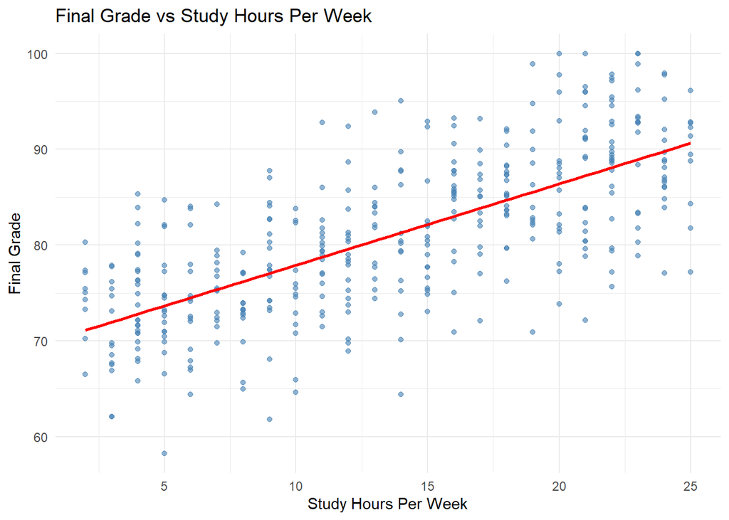

```r
# Create scatter plot
ggplot(student_data, aes(x = study_hours_per_week, y = final_grade)) +
  geom_point(alpha = 0.6, color = "steelblue") +
  geom_smooth(method = "lm", se = FALSE, color = "red") +
  labs(title = "Final Grade vs Study Hours Per Week",
       x = "Study Hours Per Week",
       y = "Final Grade") +
  theme_minimal()
```

**Question:** Which existing numerical variable has the strongest correlation with `final_grade`?

## Task 2: Time-Based Feature Engineering (10 minutes)

Create a new feature that captures how long each student has been in the current semester.

### 2.1 Create Days Since Semester Start

```r
# Create a feature for days since semester start
student_data <- student_data %>%
  mutate(
    days_since_semester_start = as.numeric(Sys.Date() - semester_start_date)
  )

head(student_data %>% select(semester_start_date, days_since_semester_start))
```

```
## # A tibble: 6 × 2
##   semester_start_date days_since_semester_start
##   <date>                                  <dbl>
## 1 2024-01-18                                614
## 2 2024-01-18                                614
## 3 2024-01-24                                608
## 4 2024-01-05                                627
## 5 2024-01-24                                608
## 6 2024-01-06                                626
```

### 2.2 Analyze the New Time Feature

Calculate the correlation between your new time feature and `final_grade`, then compare it to the baseline correlations.

```r
# Calculate correlation with new time feature
cor_days_since <- cor(student_data$final_grade, student_data$days_since_semester_start)

cat("Baseline correlations:\n")
```

```
## Baseline correlations:
```

```r
cat("Study hours per week:", round(cor_study_hours, 3), "\n")
```

```
## Study hours per week: 0.7
```

```r
cat("Attendance rate:", round(cor_attendance, 3), "\n")
```

```
## Attendance rate: 0.261
```

```r
cat("Previous grade:", round(cor_previous, 3), "\n\n")
```

```
## Previous grade: 0.231
```

```r
cat("New time-based feature:\n")
```

```
## New time-based feature:
```

```r
cat("Days since semester start:", round(cor_days_since, 3), "\n")
```

```
## Days since semester start: -0.031
```

**Question:** Does the time-based feature improve our predictive power compared to the original variables?

**Answer:** No, the days since semester start has a very weak correlation (close to 0) with final grade, so it doesn’t improve our predictive power compared to the existing variables.

## Task 3: Categorical Feature Engineering (10 minutes)

Apply one-hot encoding to the categorical variables and analyze their relationships with `final_grade`.

### 3.1 One-Hot Encode Categorical Variables

```r
# Apply one-hot encoding to major, has_job, and class_level
encoded_data <- student_data %>%
  dummy_cols(select_columns = c("major", "has_job", "class_level"),
             remove_first_dummy = FALSE)

# Show the new columns
head(encoded_data %>% select(major, starts_with("major_")))
```

```
## # A tibble: 6 × 5
##   major        major_Arts major_Business `major_Liberal Arts` major_STEM
##   <chr>             <int>          <int>                <int>      <int>
## 1 Business              0              1                    0          0
## 2 STEM                  0              0                    0          1
## 3 Liberal Arts          0              0                    1          0
## 4 STEM                  0              0                    0          1
## 5 STEM                  0              0                    0          1
## 6 Liberal Arts          0              0                    1          0
```

### 3.2 Analyze Categorical Feature Correlations

Calculate correlations between all the new binary variables and `final_grade`.

```r
# Calculate correlations for encoded categorical variables
# Major correlations
cor_stem <- cor(encoded_data$final_grade, encoded_data$major_STEM)
cor_liberal_arts <- cor(encoded_data$final_grade, encoded_data$`major_Liberal Arts`)
cor_business <- cor(encoded_data$final_grade, encoded_data$major_Business)
cor_arts <- cor(encoded_data$final_grade, encoded_data$major_Arts)

# Job correlations
cor_job_yes <- cor(encoded_data$final_grade, encoded_data$has_job_Yes)
cor_job_no <- cor(encoded_data$final_grade, encoded_data$has_job_No)

# Class level correlations
cor_freshman <- cor(encoded_data$final_grade, encoded_data$class_level_Freshman)
cor_sophomore <- cor(encoded_data$final_grade, encoded_data$class_level_Sophomore)
cor_junior <- cor(encoded_data$final_grade, encoded_data$class_level_Junior)
cor_senior <- cor(encoded_data$final_grade, encoded_data$class_level_Senior)

cat("Major correlations:\n")
```

```
## Major correlations:
```

```r
cat("STEM:", round(cor_stem, 3), "\n")
```

```
## STEM: 0.091
```

```r
cat("Liberal Arts:", round(cor_liberal_arts, 3), "\n")
```

```
## Liberal Arts: -0.003
```

```r
cat("Business:", round(cor_business, 3), "\n")
```

```
## Business: 0.007
```

```r
cat("Arts:", round(cor_arts, 3), "\n\n")
```

```
## Arts: -0.107
```

```r
cat("Job status correlations:\n")
```

```
## Job status correlations:
```

```r
cat("Has job (Yes):", round(cor_job_yes, 3), "\n")
```

```
## Has job (Yes): -0.095
```

```r
cat("No job (No):", round(cor_job_no, 3), "\n\n")
```

```
## No job (No): 0.095
```

```r
cat("Class level correlations:\n")
```

```
## Class level correlations:
```

```r
cat("Freshman:", round(cor_freshman, 3), "\n")
```

```
## Freshman: 0.028
```

```r
cat("Sophomore:", round(cor_sophomore, 3), "\n")
```

```
## Sophomore: 0.019
```

```r
cat("Junior:", round(cor_junior, 3), "\n")
```

```
## Junior: -0.019
```

```r
cat("Senior:", round(cor_senior, 3), "\n")
```

```
## Senior: -0.03
```

**Question:** Which major shows the strongest positive correlation with final grades? Which shows the strongest negative correlation?

**Answer:** STEM shows the strongest positive correlation with final grades, while Arts shows the strongest negative correlation. Having a job shows a negative correlation with grades.

## Task 4: Interaction and Polynomial Features (10 minutes)

Create more complex features using interactions and polynomial transformations.

### 4.1 Create an Interaction Term

Create an interaction between `study_hours_per_week` and `attendance_rate`.

```r
# Create interaction between study_hours_per_week and attendance_rate
student_data <- student_data %>%
  mutate(
    study_hours_x_attendance = study_hours_per_week * attendance_rate
  )

head(student_data %>% select(study_hours_per_week, attendance_rate, study_hours_x_attendance))
```

```
## # A tibble: 6 × 3
##   study_hours_per_week attendance_rate study_hours_x_attendance
##                  <dbl>           <dbl>                    <dbl>
## 1                    4              85                      340
## 2                    7              75                      525
## 3                   19              94                     1786
## 4                   22              79                     1738
## 5                   20              80                     1600
## 6                   10              73                      730
```

### 4.2 Create a Polynomial Feature

Create a squared term for one of your numerical variables (choose the one you think might benefit most from a non-linear transformation).

```r
# Create polynomial feature - squaring study_hours_per_week since it has strongest correlation
student_data <- student_data %>%
  mutate(
    study_hours_squared = study_hours_per_week^2
  )

head(student_data %>% select(study_hours_per_week, study_hours_squared))
```

```
## # A tibble: 6 × 2
##   study_hours_per_week study_hours_squared
##                  <dbl>               <dbl>
## 1                    4                  16
## 2                    7                  49
## 3                   19                 361
## 4                   22                 484
## 5                   20                 400
## 6                   10                 100
```

### 4.3 Evaluate Complex Features

Compare the correlations of your interaction and polynomial features with `final_grade`.

```r
# Calculate correlations for complex features
cor_interaction <- cor(student_data$final_grade, student_data$study_hours_x_attendance)
cor_polynomial <- cor(student_data$final_grade, student_data$study_hours_squared)

cat("Original feature correlations:\n")
```

```
## Original feature correlations:
```

```r
cat("Study hours per week:", round(cor_study_hours, 3), "\n")
```

```
## Study hours per week: 0.7
```

```r
cat("Attendance rate:", round(cor_attendance, 3), "\n\n")
```

```
## Attendance rate: 0.261
```

```r
cat("Engineered feature correlations:\n")
```

```
## Engineered feature correlations:
```

```r
cat("Study hours × Attendance interaction:", round(cor_interaction, 3), "\n")
```

```
## Study hours × Attendance interaction: 0.735
```

```r
cat("Study hours squared:", round(cor_polynomial, 3), "\n")
```

```
## Study hours squared: 0.689
```

**Question:** Do the interaction or polynomial features show stronger correlations than the original variables?

## Task 5: Visualization and Interpretation (7 minutes)

Create visualizations to better understand your engineered features.

### 5.1 Visualize the Interaction Effect

Create a plot that demonstrates why the interaction term (study_hours_x_attendance) is more powerful than individual variables. Show how the relationship between study hours and final grade varies by attendance levels.

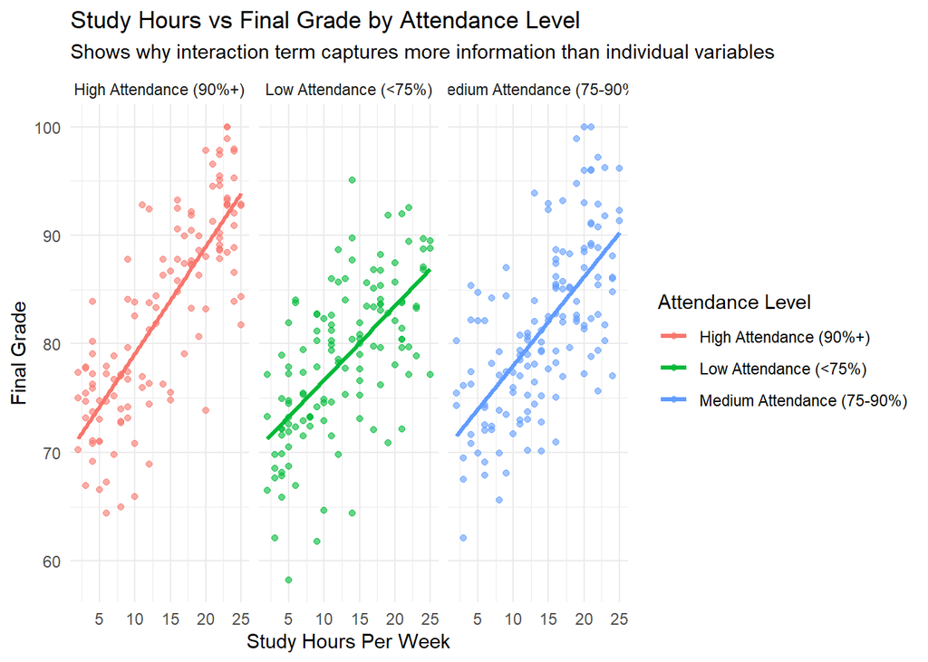

```r
# First, create attendance level bins to show the interaction effect
# Hint: Use case_when() to create categorical bins from continuous attendance_rate
student_data <- student_data %>%
  mutate(
    attendance_level = case_when(
      attendance_rate < 75 ~ "Low Attendance (<75%)",
      attendance_rate < 90 ~ "Medium Attendance (75-90%)",
      TRUE ~ "High Attendance (90%+)"
    )
  )

# Create visualization showing how study hours effect varies by attendance level
ggplot(student_data, aes(x = study_hours_per_week, y = final_grade, color = attendance_level)) +
  geom_point(alpha = 0.6) +
  geom_smooth(method = "lm", se = FALSE, size = 1.2) +
  labs(title = "Study Hours vs Final Grade by Attendance Level",
       subtitle = "Shows why interaction term captures more information than individual variables",
       x = "Study Hours Per Week",
       y = "Final Grade",
       color = "Attendance Level") +
  theme_minimal() +
  facet_wrap(~attendance_level)
```

### 5.2 Feature Importance Summary

Create a summary table or visualization showing the correlation strengths of all your engineered features.

```r
# Create summary of feature correlations
correlation_summary <- tibble(
  Feature = c("Study Hours", "Attendance Rate", "Previous Grade", "Days Since Start",
              "STEM Major", "Liberal Arts", "Business", "Arts", "Has Job",
              "Study Hours × Attendance", "Study Hours²"),
  Correlation = c(cor_study_hours, cor_attendance, cor_previous, cor_days_since,
                  cor_stem, cor_liberal_arts, cor_business, cor_arts, cor_job_yes,
                  cor_interaction, cor_polynomial)
) %>%
  arrange(desc(abs(Correlation)))

print(correlation_summary)
```

```
## # A tibble: 11 × 2
##    Feature                  Correlation
##    <chr>                          <dbl>
##  1 Study Hours × Attendance     0.735
##  2 Study Hours                  0.700
##  3 Study Hours²                 0.689
##  4 Attendance Rate              0.261
##  5 Previous Grade               0.231
##  6 Arts                        -0.107
##  7 Has Job                     -0.0953
##  8 STEM Major                   0.0914
##  9 Days Since Start            -0.0311
## 10 Business                     0.00720
## 11 Liberal Arts                -0.00273
```

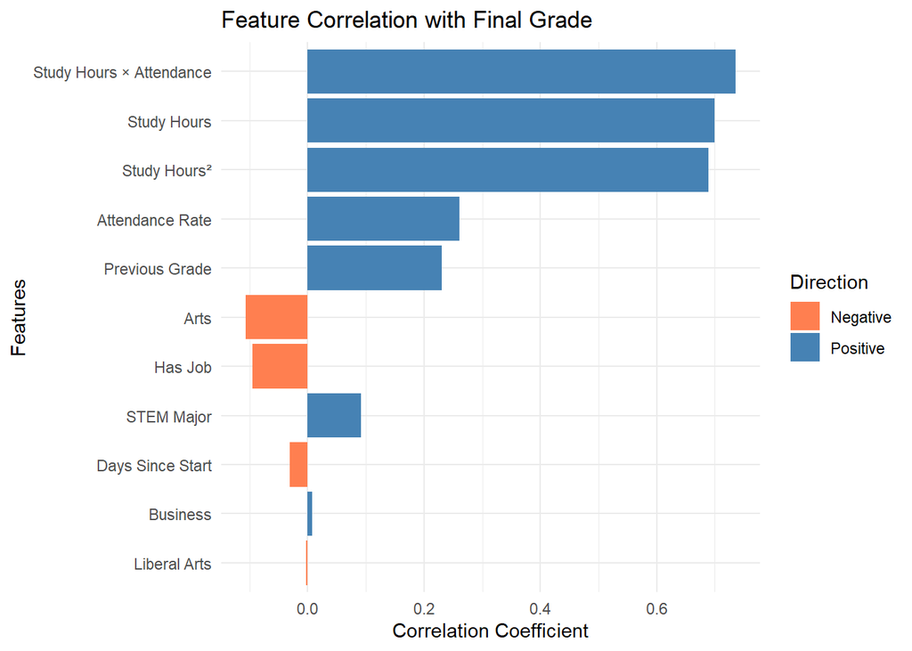

```r
# Visualize feature importance
ggplot(correlation_summary, aes(x = reorder(Feature, abs(Correlation)), y = Correlation)) +
  geom_col(aes(fill = ifelse(Correlation > 0, "Positive", "Negative"))) +
  coord_flip() +
  labs(title = "Feature Correlation with Final Grade",
       x = "Features",
       y = "Correlation Coefficient",
       fill = "Direction") +
  theme_minimal() +
  scale_fill_manual(values = c("Negative" = "coral", "Positive" = "steelblue"))
```

## Reflection Questions (5 minutes)

Answer these questions based on your analysis:

1. **Which engineered feature was most effective?**

   *Answer:* Possible answers include: study efficiency (previous_grade/study_hours), attendance improvement (current vs historical attendance), major difficulty adjustments, interaction between having a job and study hours, etc.
4. **How might these engineered features improve a predictive model compared to using only the original variables?**

   *Answer:* The engineered features capture non-linear relationships and interactions that linear models couldn’t detect with original variables alone. The interaction term especially shows that the combined effect of study hours and attendance is stronger than either alone.

## Bonus Challenges (If Time Permits)

Choose one or more of these additional challenges:

### Bonus 1: Grade Risk Categories

Create a “grade risk” categorical feature that bins students into “High Risk” (final_grade < 70), “Medium Risk” (70-85), and “Low Risk” (>85) categories. Then analyze which of your engineered features best predict this risk level.

```r
# Bonus 1: Create grade risk categories and analyze predictive features
student_data <- student_data %>%
  mutate(
    grade_risk = case_when(
      final_grade < 70 ~ "High Risk",
      final_grade < 85 ~ "Medium Risk",
      TRUE ~ "Low Risk"
    ),
    grade_risk_numeric = case_when(
      grade_risk == "High Risk" ~ 1,
      grade_risk == "Medium Risk" ~ 2,
      grade_risk == "Low Risk" ~ 3
    )
  )

# Analyze which features best predict grade risk
cor_risk_study <- cor(student_data$grade_risk_numeric, student_data$study_hours_per_week)
cor_risk_interaction <- cor(student_data$grade_risk_numeric, student_data$study_hours_x_attendance)

cat("Correlation with Grade Risk Level:\n")
```

```
## Correlation with Grade Risk Level:
```

```r
cat("Study Hours:", round(cor_risk_study, 3), "\n")
```

```
## Study Hours: 0.629
```

```r
cat("Study Hours × Attendance:", round(cor_risk_interaction, 3), "\n")
```

```
## Study Hours × Attendance: 0.663
```

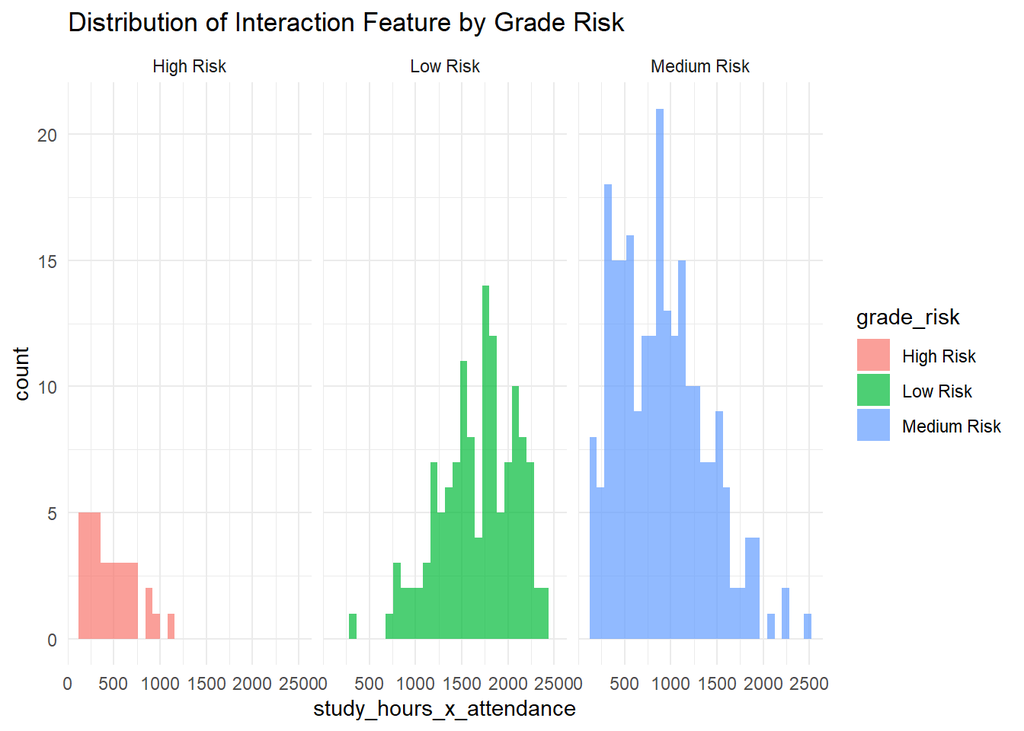

```r
# Visualize
ggplot(student_data, aes(x = study_hours_x_attendance, fill = grade_risk)) +
  geom_histogram(alpha = 0.7, position = "identity") +
  facet_wrap(~grade_risk) +
  labs(title = "Distribution of Interaction Feature by Grade Risk") +
  theme_minimal()
```

### Bonus 2: Advanced Interaction Terms

Create a three-way interaction term combining `study_hours_per_week`, `attendance_rate`, and `previous_grade`. Compare its predictive power to your two-way interactions.

```r
# Bonus 2: Create three-way interaction term
student_data <- student_data %>%
  mutate(
    three_way_interaction = study_hours_per_week * attendance_rate * previous_grade
  )

cor_three_way <- cor(student_data$final_grade, student_data$three_way_interaction)

cat("Correlation Comparison:\n")
```

```
## Correlation Comparison:
```

```r
cat("Two-way interaction (Study Hours × Attendance):", round(cor_interaction, 3), "\n")
```

```
## Two-way interaction (Study Hours × Attendance): 0.735
```

```r
cat("Three-way interaction:", round(cor_three_way, 3), "\n")
```

```
## Three-way interaction: 0.761
```

### Bonus 3: Binning Continuous Variables

Convert `study_hours_per_week` into categorical bins (e.g., “Low”, “Medium”, “High” study hours) and create dummy variables. Compare the correlation of these bins with the original continuous variable.

```r
# Bonus 3: Create study hours bins and dummy variables
student_data <- student_data %>%
  mutate(
    study_hours_bins = case_when(
      study_hours_per_week <= 8 ~ "Low",
      study_hours_per_week <= 16 ~ "Medium",
      TRUE ~ "High"
    )
  )

# Create dummy variables for bins
binned_data <- student_data %>%
  dummy_cols(select_columns = "study_hours_bins")

# Calculate correlations
cor_low <- cor(binned_data$final_grade, binned_data$study_hours_bins_Low)
cor_medium <- cor(binned_data$final_grade, binned_data$study_hours_bins_Medium)
cor_high <- cor(binned_data$final_grade, binned_data$study_hours_bins_High)

cat("Original continuous variable correlation:", round(cor_study_hours, 3), "\n")
```

```
## Original continuous variable correlation: 0.7
```

```r
cat("Binned variable correlations:\n")
```

```
## Binned variable correlations:
```

```r
cat("Low study hours:", round(cor_low, 3), "\n")
```

```
## Low study hours: -0.553
```

```r
cat("Medium study hours:", round(cor_medium, 3), "\n")
```

```
## Medium study hours: -0.097
```

```r
cat("High study hours:", round(cor_high, 3), "\n")
```

```
## High study hours: 0.606
```

### Bonus 4: Feature Scaling and Normalization

Create standardized (z-score) versions of your numerical features and compare their correlations with the original features. Does scaling change the relationships?

```r
# Bonus 4: Create standardized features
student_data <- student_data %>%
  mutate(
    study_hours_standardized = scale(study_hours_per_week)[,1],
    attendance_standardized = scale(attendance_rate)[,1],
    previous_grade_standardized = scale(previous_grade)[,1]
  )

# Compare correlations
cor_study_std <- cor(student_data$final_grade, student_data$study_hours_standardized)
cor_attend_std <- cor(student_data$final_grade, student_data$attendance_standardized)
cor_previous_std <- cor(student_data$final_grade, student_data$previous_grade_standardized)

cat("Original vs Standardized Correlations:\n")
```

```
## Original vs Standardized Correlations:
```

```r
cat("Study Hours - Original:", round(cor_study_hours, 3), "| Standardized:", round(cor_study_std, 3), "\n")
```

```
## Study Hours - Original: 0.7 | Standardized: 0.7
```

```r
cat("Attendance - Original:", round(cor_attendance, 3), "| Standardized:", round(cor_attend_std, 3), "\n")
```

```
## Attendance - Original: 0.261 | Standardized: 0.261
```

```r
cat("Previous Grade - Original:", round(cor_previous, 3), "| Standardized:", round(cor_previous_std, 3), "\n")
```

```
## Previous Grade - Original: 0.231 | Standardized: 0.231
```

```r
cat("\nScaling does not change correlations - they remain identical!\n")
```

```
##
## Scaling does not change correlations - they remain identical!
```

### Bonus 5: Class Level Ordering

Convert the `class_level` variable into an ordinal numeric variable (Freshman=1, Sophomore=2, etc.) and compare its correlation with `final_grade` to the one-hot encoded versions.

```r
# Bonus 5: Create ordinal class level variable
student_data <- student_data %>%
  mutate(
    class_level_numeric = case_when(
      class_level == "Freshman" ~ 1,
      class_level == "Sophomore" ~ 2,
      class_level == "Junior" ~ 3,
      class_level == "Senior" ~ 4
    )
  )

cor_class_numeric <- cor(student_data$final_grade, student_data$class_level_numeric)

cat("Class Level Correlations:\n")
```

```
## Class Level Correlations:
```

```r
cat("Ordinal numeric version:", round(cor_class_numeric, 3), "\n")
```

```
## Ordinal numeric version: -0.042
```

```r
cat("One-hot encoded versions:\n")
```

```
## One-hot encoded versions:
```

```r
cat("Freshman:", round(cor_freshman, 3), "\n")
```

```
## Freshman: 0.028
```

```r
cat("Sophomore:", round(cor_sophomore, 3), "\n")
```

```
## Sophomore: 0.019
```

```r
cat("Junior:", round(cor_junior, 3), "\n")
```

```
## Junior: -0.019
```

```r
cat("Senior:", round(cor_senior, 3), "\n")
```

```
## Senior: -0.03
```

```r
# The ordinal version captures the overall trend, while one-hot shows individual class effects
```